# BF_HW_ARIMA

aa2569@scarletmail.rutgers.edu

11/10/2022

```r
library(fpp)
library(fpp2)
library(forecast)
```

## Data set - cafe (fpp)

#### Cafe plot

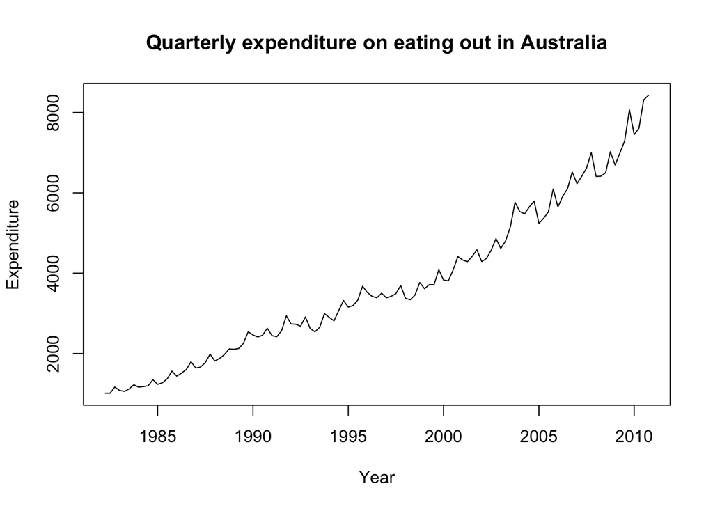

```r
plot(cafe, main = 'Quarterly expenditure on eating out in Australia', xlab = 'Year', ylab = 'Expenditure')
```

- We can see that the data has both trend and seasonality.
- Upon testing various forecast methods earlier, we have seen an increase in the residuals towards the end everytime.
- Which signifies that the latest data is quite different compared to the data in the past.
- So, here we going to consider a window of the data from 2005.

#### Window Plot

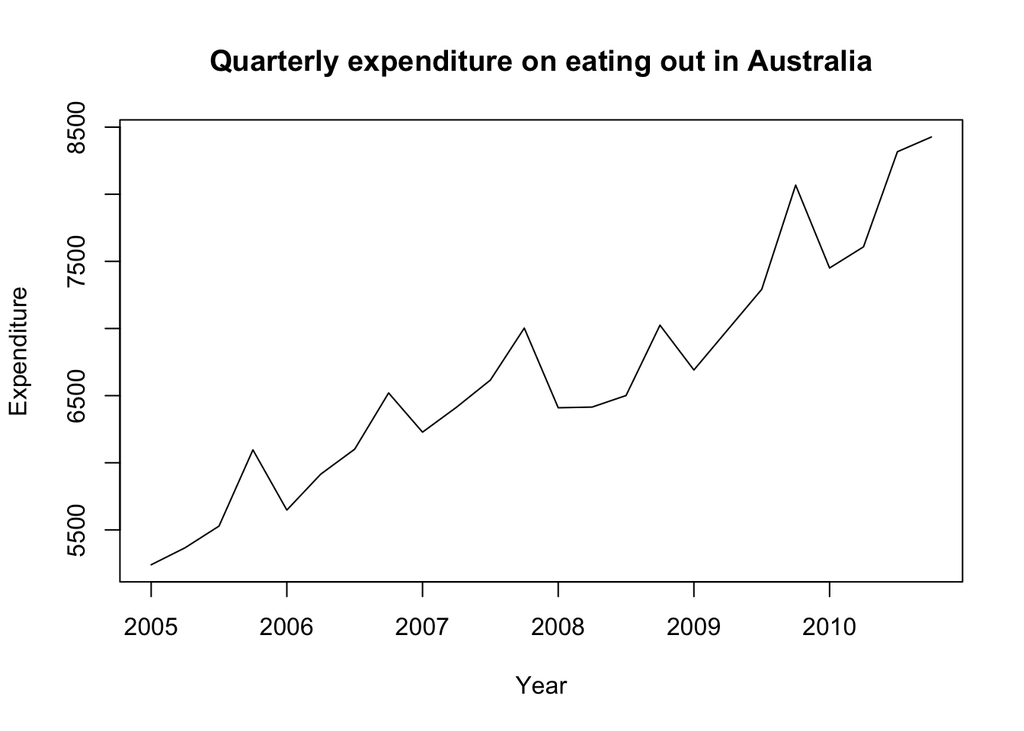

```r
cafe_win <- window(cafe, start = 2005)
plot(cafe_win, main = 'Quarterly expenditure on eating out in Australia', xlab = 'Year', ylab = 'Expenditure')
```

- Even here, we can observe both trend and seasonality from the first glance.
- We can check this with an Acf function.

#### Acf plot

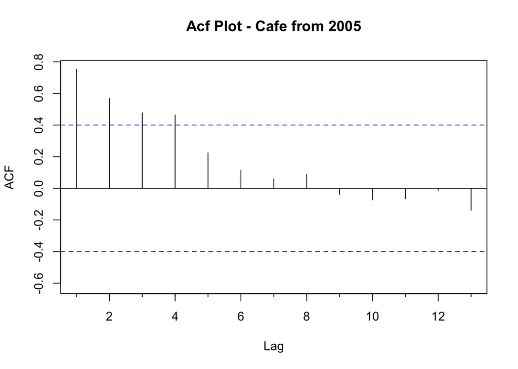

```r
Acf(cafe_win, main = 'Acf Plot - Cafe from 2005')
```

- The Acf plot shows both trend and seasonality presense here.
- As there is seasonality we use both nsdiffs and ndiffs.

## ARIMA for data with seasonal component

#### Checking the Differencing needed for seasonal component

```r
nsdiffs(cafe_win) #nsdiffs is for seasonal
```

```
## [1] 1
```

- nsdiffs is use to know how many differences we need to do for seasonality component.
- We first go ahead with seasonality beacuse most of the cases, ones we do this, trend takes care of itself.

#### Checking the Differences needed

```r
ndiffs(cafe_win)
```

```
## [1] 1
```

- We got ndiffs as 1 initially.
- Let us first performs the differences for seasonal data and check ndiffs again.

#### Rechecking the differencing needed after performing the seasonal differencing

```r
ndiffs((diff(cafe_win,4))) #4 because it is quarterly
```

```
## [1] 0
```

- As mentioned above, we can see that the ndiffs now becomes zero indicating that the trend component took care of itself.

#### Acf and Pacf plots

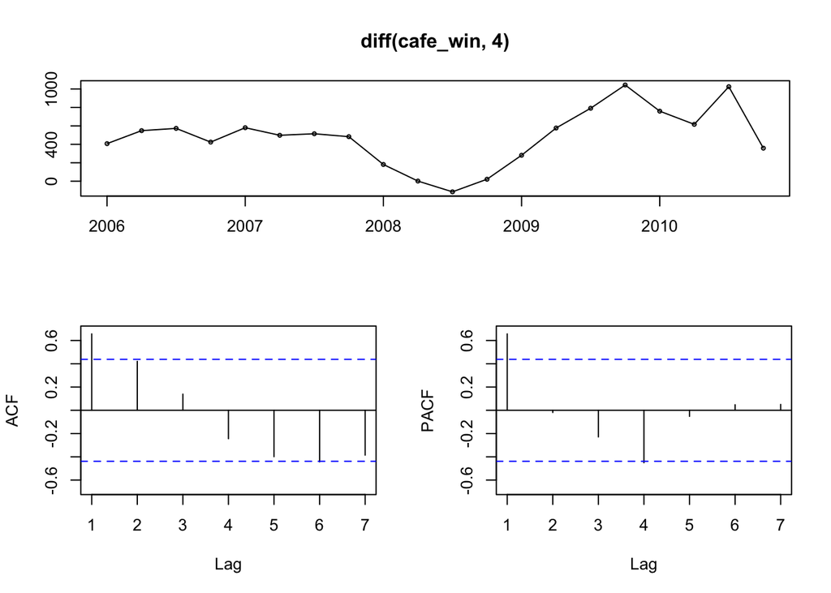

```r
tsdisplay(diff(cafe_win,4))
```

- In the Acf plot we can see that the p value is 1 and the q values is 1.
- So, the model takes values of 0,1 for p and q.
- In the Pacf plot, we can see that the P value is 1 and the Q value is 1.
- So, the model takes values of 0,1 for P and Q.
- However, the model also tests values other than the above to check if there is a better model with lesser AIC.

#### Arima Model

```r
arima_fit <- auto.arima(cafe_win,trace=TRUE, stepwise = FALSE )
```

```
##
##  ARIMA(0,0,0)(0,1,0)[4]                    : 312.3992
##  ARIMA(0,0,0)(0,1,0)[4] with drift         : 289.47
##  ARIMA(0,0,0)(0,1,1)[4]                    : 309.7497
##  ARIMA(0,0,0)(0,1,1)[4] with drift         : Inf
##  ARIMA(0,0,0)(0,1,2)[4]                    : 312.5036
##  ARIMA(0,0,0)(0,1,2)[4] with drift         : Inf
##  ARIMA(0,0,0)(1,1,0)[4]                    : 308.2182
##  ARIMA(0,0,0)(1,1,0)[4] with drift         : 290.9323
##  ARIMA(0,0,0)(1,1,1)[4]                    : Inf
##  ARIMA(0,0,0)(1,1,1)[4] with drift         : Inf
##  ARIMA(0,0,0)(1,1,2)[4]                    : Inf
##  ARIMA(0,0,0)(1,1,2)[4] with drift         : Inf
##  ARIMA(0,0,0)(2,1,0)[4]                    : 309.5351
##  ARIMA(0,0,0)(2,1,0)[4] with drift         : Inf
##  ARIMA(0,0,0)(2,1,1)[4]                    : Inf
##  ARIMA(0,0,0)(2,1,1)[4] with drift         : Inf
##  ARIMA(0,0,0)(2,1,2)[4]                    : Inf
##  ARIMA(0,0,0)(2,1,2)[4] with drift         : Inf
##  ARIMA(0,0,1)(0,1,0)[4]                    : Inf
##  ARIMA(0,0,1)(0,1,0)[4] with drift         : Inf
##  ARIMA(0,0,1)(0,1,1)[4]                    : Inf
##  ARIMA(0,0,1)(0,1,1)[4] with drift         : Inf
##  ARIMA(0,0,1)(0,1,2)[4]                    : Inf
##  ARIMA(0,0,1)(0,1,2)[4] with drift         : Inf
##  ARIMA(0,0,1)(1,1,0)[4]                    : Inf
##  ARIMA(0,0,1)(1,1,0)[4] with drift         : Inf
##  ARIMA(0,0,1)(1,1,1)[4]                    : Inf
##  ARIMA(0,0,1)(1,1,1)[4] with drift         : Inf
##  ARIMA(0,0,1)(1,1,2)[4]                    : Inf
##  ARIMA(0,0,1)(1,1,2)[4] with drift         : Inf
##  ARIMA(0,0,1)(2,1,0)[4]                    : Inf
##  ARIMA(0,0,1)(2,1,0)[4] with drift         : Inf
##  ARIMA(0,0,1)(2,1,1)[4]                    : Inf
##  ARIMA(0,0,1)(2,1,1)[4] with drift         : Inf
##  ARIMA(0,0,1)(2,1,2)[4]                    : Inf
##  ARIMA(0,0,1)(2,1,2)[4] with drift         : Inf
##  ARIMA(0,0,2)(0,1,0)[4]                    : 294.7852
##  ARIMA(0,0,2)(0,1,0)[4] with drift         : 284.6931
##  ARIMA(0,0,2)(0,1,1)[4]                    : 296.9012
```

[output cut: 122 more lines]

```
##  ARIMA(3,0,0)(1,1,1)[4] with drift         : Inf
##  ARIMA(3,0,0)(2,1,0)[4]                    : Inf
##  ARIMA(3,0,0)(2,1,0)[4] with drift         : Inf
##  ARIMA(3,0,1)(0,1,0)[4]                    : Inf
##  ARIMA(3,0,1)(0,1,0)[4] with drift         : Inf
##  ARIMA(3,0,1)(0,1,1)[4]                    : Inf
##  ARIMA(3,0,1)(0,1,1)[4] with drift         : Inf
##  ARIMA(3,0,1)(1,1,0)[4]                    : Inf
##  ARIMA(3,0,1)(1,1,0)[4] with drift         : Inf
##  ARIMA(3,0,2)(0,1,0)[4]                    : Inf
##  ARIMA(3,0,2)(0,1,0)[4] with drift         : Inf
##
##
##
##  Best model: ARIMA(1,0,0)(0,1,0)[4] with drift
```

```r
arima_fit
```

```
## Series: cafe_win
## ARIMA(1,0,0)(0,1,0)[4] with drift
##
## Coefficients:
##          ar1     drift
##       0.6344  116.1067
## s.e.  0.1603   31.7566
##
## sigma^2 = 56016:  log likelihood = -136.92
## AIC=279.83   AICc=281.33   BIC=282.82
```

- The system runs the auto arima and gives out the best model for which the AIC value is the lowest.
- We can see that the model tested multiple p,q,P,Q values other than the ones we predicted earlier.
- Finally the best model has p = 1, q = 0, P = 0, Q = 0.

#### Arima Model attributes

```r
attributes(arima_fit)
```

```
## $names
##  [1] "coef"      "sigma2"    "var.coef"  "mask"      "loglik"    "aic"
##  [7] "arma"      "residuals" "call"      "series"    "code"      "n.cond"
## [13] "nobs"      "model"     "xreg"      "bic"       "aicc"      "x"
## [19] "fitted"
##
## $class
## [1] "forecast_ARIMA" "ARIMA"          "Arima"
```

#### Plotting forecast of the Arima model with 99.5% confidence

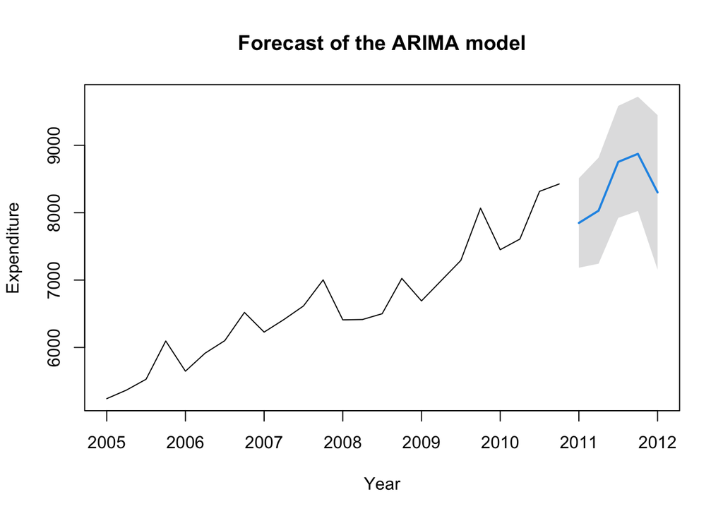

```r
plot(forecast(arima_fit,h=5,level=c(99.5)), main = 'Forecast of the ARIMA model', xlab = 'Year', ylab = 'Expenditure')
```

## Residual Analysis

#### Acf of Residuals

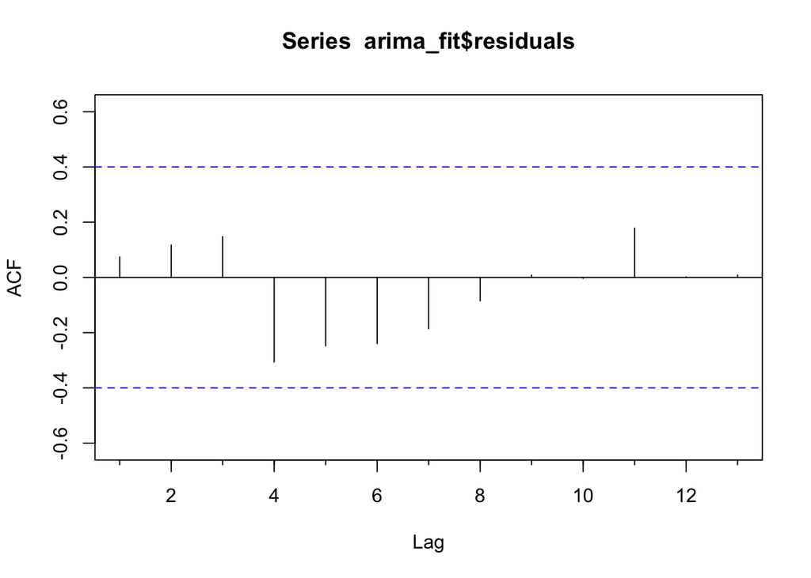

```r
Acf(arima_fit$residuals)
```

- The Acf plot of the residuals shows white noice.
- None of the data passes the confidence interval limits.
- Which means that the forecast is a good forecast.

#### Box-Ljung test

```r
Box.test(residuals(arima_fit), lag=20, type="Ljung")
```

```
##
##  Box-Ljung test
##
## data:  residuals(arima_fit)
## X-squared = 14.619, df = 20, p-value = 0.7978
```

- The p-value is greater than 0.05 meaning the null hypothesis is supported.
- The residuals are random.

#### Residuals plot

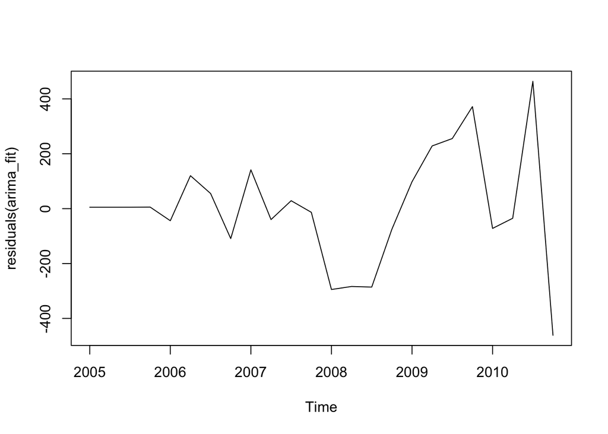

```r
plot.ts(residuals(arima_fit))
```

- The residuals appear to be random.
- The residuals seem to the mean around zero.
- This suggests that it is a goof forecasting model.

#### Histogram plot of residuals

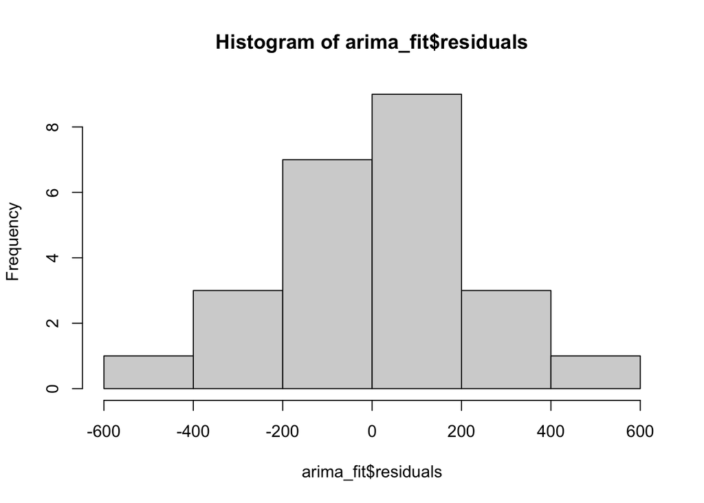

```r
hist(arima_fit$residuals)
```

- The histogram shows that the residuals have a mean of zero.
- The distribution is not a perfect normal distribution.
- The residuals are skewed to some extent.

#### TSDiagram of the ARIMA model

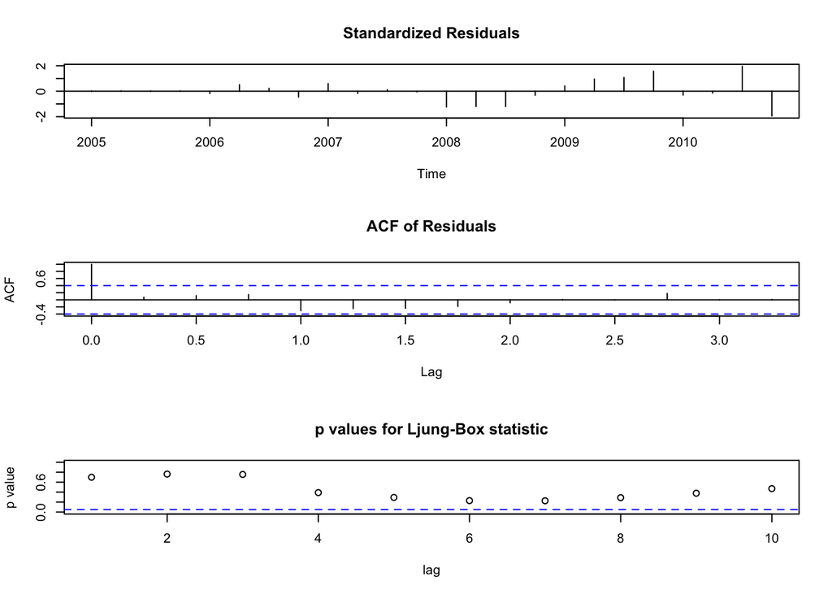

```r
tsdiag(arima_fit)
```

- The tsdiag() shows the overall residual analysis plots.
- The standardized residuals plot looks good. 2 residuals are very close to touch the z-score of 2 but did not touch the line.
- There are no significant values in the Acf plot.
- The p-values in Ljung-Box test are also above level, meaning the residuals are random.
- Overall, this ARIMA model is a good fit.